# Lecture 2 : Application

*November, 2021 - updated on April, 2022 - François HU*

*Master of Science - EPITA*

*This lecture is available here: https://curiousml.github.io/*

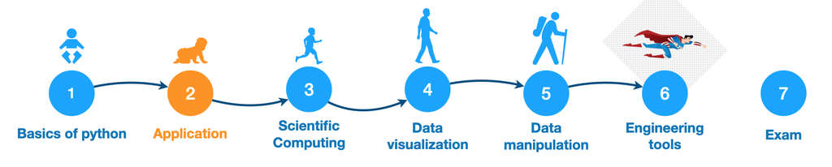

- Exercice 1
- Exercice 2
- Exercice 3

## Exercice 1: lists

1. Create a list `list_` which holds the values $[1, 4, 9, 16, 25, \dots, 400]$. **Example:**

   ```
   >>> list_[0]
   1
   >>> list_[10]
   121
   >>> list_[-1]
   400
   ```

2. Create a function `inter_in(l, i, j)` that swaps the values in position `i` and `j` of the list `l`.

**Remark:** no need for the function to return an object !

**Example:**

```
>>> inter_in(list_, 0, 10)
>>> list_[0]
121
>>> list_[10]
1
>>> inter_in(list_, 0, 10)
>>> list_[0]
1
>>> list_[10]
121
```

1. Create a function `inter_out(l, i, j)` that returns a copy of the list `l` in which the values in positions `i` and `j` are swapped. **Example:**

   ```
   >>> clist = inter_out(list_, 0, 10)
   >>> clist[0]
   121
   >>> clist[10]
   1
   >>> list_[0]
   1
   >>> list_[10]
   121
   ```

   **Hint:** Use the method `copy` of the built-in object `list` (lists are mutable).

```python
## WRITE IN THIS CELL YOUR CODE WITHOUT ANY ERRORS. YOU SHOULD GENERATE THE LIST: list_
## question 1
```

```python
## WRITE IN THIS CELL YOUR CODE WITHOUT ANY ERRORS. YOU SHOULD GENERATE THE FUNCTION: inter_in
## question 2
```

```python
## WRITE IN THIS CELL YOUR CODE WITHOUT ANY ERRORS. YOU SHOULD GENERATE THE FUNCTION: inter_out
## question 3
```

## Exercice 2: dictionaries

We have the following dictionary which contains students grade (don't forget to execute the cell):

```python
# DON'T MODIFY THIS PROGRAM, JUST EXECUTE IT
students = {'Name': ['Arthur',
                     'Marcial',
                     'Margaux',
                     'François',
                     'Julie',
                     'Sophie',
                     'Alex',
                     'Christine'
                    ],
            'Grade': [8, 2, 15, 3, 7, 10, 11, 16]}
```

The teacher wants to reajust the grades and decides to add 5 points to the grade of each student. For that purpose, follow the following steps:

1. Append and add by 5 each element of the list `students['Grade']` in a new list named `ugrade`
1. In the dictionary `students`, add a new field named `Ugrade` with `ugrade` as an item.

Even after the reajustment, some students have less than 10 points so therefore they need to do a rattrapage examination.

1. Create a new dictionary named `retake_examination` which contains the `Name`, `Grade` and `Ugrade` of the students who need to retake the examination.

```python
## WRITE IN THIS CELL YOUR CODE WITHOUT ANY ERRORS. YOU SHOULD GENERATE THE LIST: ugrade
## question 1
```

```python
## WRITE IN THIS CELL YOUR CODE WITHOUT ANY ERRORS. YOU SHOULD UPDATE THE DICITONARY: students
## question 2
```

```python
## WRITE IN THIS CELL YOUR CODE WITHOUT ANY ERRORS. YOU SHOULD GENERATE THE DICITONARY: retake_examination
## question 3
```

## Exercice 3: strings

1. Create a function `signature(text)` which returns the string `text` with `" EPITA."` at the end. **Remark:** be careful, we have a space and `.` in the signature.

**Example:**

```
>>> signature('Hello world!')
'Hello world! EPITA.'
>>> signature("Don't be late for the test.")
"Don't be late for the test. EPITA."
```

1. Create a function `delete_signature(text)` which returns the string `text` with `" EPITA."` at the end deleted. If the substring `" EPITA."` does not exist, then do nothing. **Example:**

   ```
   >>> delete_signature('Hello world! EPITA.')
   'Hello world!'
   >>> delete_signature("Don't be late for the test.")
   "Don't be late for the test."
   >>> delete_signature('Hello world! EPITA')
   'Hello world! EPITA'
   ```

   **Hints:** a string is a container where:
- we can access to the last 7 characters of a string `text` with `text[-7:]`;
- we can access to all the characters of a string `text` except the last 7 characters with `text[:-7]`.

```python
## WRITE IN THIS CELL YOUR CODE WITHOUT ANY ERRORS. YOU SHOULD GENERATE THE FUNCTION: signature
## question 1
```

```python
## WRITE IN THIS CELL YOUR CODE WITHOUT ANY ERRORS. YOU SHOULD GENERATE THE FUNCTION: delete_signature
## question 2
```